# 21966155 - A3

*) Loading all needed package:

```r
library(readr)
library(readxl)
library(ggplot2)
library(tidyverse)
library(dplyr)
library(stringr)
#install.packages("Hmisc")
library(Hmisc)
```

TASK 1:

```r
employee_demographics <- read.csv("survey_employee_demographics.csv", na.strings = c("", "-", "--"))
employee_employment_details <- read_excel("survey_employee_employment_details.xlsx", na = c("", "-", "--"))
combined_employee <- merge(employee_demographics, employee_employment_details, by = "RecordID")
combined_employee
```

| RecordID | Age | Gender | City | Position | TotalYearsOfExperience | YearsOfExperienceInGermany | SeniorityLevel | YourMainProgrammingLanguage | OtherProgrammingLanguagesYouUseOften | YearlyBruttoSalaryInEUR | YearlyBonusAndStocksInEUR | AnnualBruttoSalaryOneYearAgo | AnnualBonusAndStocksOneYearAgo | NumberOfVacationDays | EmploymentStatus | СontractDuration | MainLanguageAtWork | CompanySize | CompanyType | HaveYouLostYourJobDueToTheCoronavirusOutbreak | HaveYouBeenForcedToHaveAShorterWorkingWeekKnownAsKurzarbeitIfYesHowManyHoursPerWeek | HaveYouReceivedAdditionalMonetarySupportFromYourEmployerDueToWorkFromHomeIfYesHowMuchIn2020InEUR |
| --- | --- | --- | --- | --- | --- | --- | --- | --- | --- | --- | --- | --- | --- | --- | --- | --- | --- | --- | --- | --- | --- | --- |
| AAA0 | 26 | Male | Munich | Software Engineer | 5 | 3 | Senior | TypeScript | Kotlin, Javascript / Typescript | 8.000000e+04 | 5000 | 75000 | 10000 | 30 | Full-time employee | Unlimited contract | English | 51-100 | Product | No | NA | NA |
| AAB1 | 26 | Male | Berlin | Backend Developer | 7 | 4 | Senior | Ruby | NA | 8.000000e+04 | NA | 82000 | 5000 | 28 | Full-time employee | Unlimited contract | English | 101-1000 | Product | No | NA | NA |
| AAC2 | 29 | Male | Berlin | Software Engineer | 12 | 6 | Lead | Javascript / Typescript | Javascript / Typescript, Docker | 1.200000e+05 | 120000 | 100000 | 100000 | 30 | Self-employed (freelancer) | Temporary contract | English | 101-1000 | Product | Yes | NA | NA |
| AAD3 | 28 | Male | Berlin | Frontend Developer | 4 | 1 | Junior | Javascript | NA | 5.400000e+04 | NA | NA | NA | 24 | Full-time employee | Unlimited contract | English | 51-100 | Startup | No | NA | NA |
| AAE4 | 37 | Male | Berlin | Backend Developer | 17 | 6 | Senior | C# .NET | .NET, SQL, AWS, Docker | 6.200000e+04 | NA | 62000 | NA | 29 | Full-time employee | Unlimited contract | English | 101-1000 | Product | No | NA | NA |
| AAF5 | 32 | Male | Berlin | DevOps | 5 | 1 | Senior | AWS, GCP, Python,K8s | Python, AWS, Google Cloud, Kubernetes, Docker | 7.600000e+04 | 5000 | 76000 | 5000 | 30 | Full-time employee | Unlimited contract | English | 11-50 | Startup | No | NA | NA |
| AAG6 | 37 | Male | Berlin | Frontend Developer | 6 | 0.4 | Middle | Javascript | NA | 5.700000e+04 | NA | NA | NA | 24 | Full-time employee | Unlimited contract | English | 11-50 | Product | No | NA | NA |
| AAH7 | 24 | Male | Berlin | Frontend Developer | 5 | 1 | Senior | Typescript | Javascript / Typescript | 6.500000e+04 | NA | 65000 | NA | 27 | Full-time employee | Unlimited contract | English | 1000+ | Product | No | 0.0 | 600 |
| AAI8 | 29 | Male | Berlin | Backend Developer | 8 | 2 | Senior | PHP | SQL, AWS, Docker | 5.600000e+04 | NA | 55000 | NA | 28 | Full-time employee | Unlimited contract | English | 101-1000 | Product | No | 30.0 | NA |
| AAJ9 | 35 | Male | Berlin | Software Engineer | 15 | 3 | Lead | Java | NA | 9.500000e+04 | NA | 90000 | NA | 30 | Full-time employee | Unlimited contract | English | 101-1000 | Product | No | 0.0 | NA |

[output cut: 990 more lines]

TASK 2: Task 2.a:

```r
describe(combined_employee)
```

```
combined_employee

 23  Variables      1253  Observations
-----------------------------------------------------------------------------------------------------------------
RecordID
       n  missing distinct
    1253        0     1253

lowest : AAA0    AAB1    AAC2    AAD3    AAE4   , highest: BWA1248 BWB1249 BWC1250 BWD1251 BWE1252
-----------------------------------------------------------------------------------------------------------------
Age
       n  missing distinct     Info     Mean      Gmd      .05      .10      .25      .50      .75      .90
    1226       27       40    0.996    32.51    6.079     25.0     26.0     29.0     32.0     35.0     39.5
     .95
    42.0

lowest : 20 21 22 23 24, highest: 56 59 65 66 69
-----------------------------------------------------------------------------------------------------------------
Gender
       n  missing distinct
    1243       10        3

Value      Diverse  Female    Male
Frequency        2     192    1049
Proportion   0.002   0.154   0.844
-----------------------------------------------------------------------------------------------------------------
City
       n  missing distinct
    1253        0      119

lowest : Aachen    Amsterdam Ansbach   Barcelona Basel    , highest: Wolfsburg Wroclaw   Würzburg  Zurich    Zürich
-----------------------------------------------------------------------------------------------------------------
Position
       n  missing distinct
    1247        6      141

lowest : Account Managet      Agile Coach          agile master         AI Management        Analyst
highest: Testautomation       Testmanager          VP Engineering       working student (QA) XR Developer
-----------------------------------------------------------------------------------------------------------------
TotalYearsOfExperience
```

[output cut: 113 more lines]

```
HaveYouBeenForcedToHaveAShorterWorkingWeekKnownAsKurzarbeitIfYesHowManyHoursPerWeek
       n  missing distinct     Info     Mean      Gmd      .05      .10      .25      .50      .75      .90
     373      880       23    0.851    12.97    16.11        0        0        0        0       30       35
     .95
      40

lowest : 0    2    4    5    8   , highest: 36   37.5 38   39   40
-----------------------------------------------------------------------------------------------------------------
HaveYouReceivedAdditionalMonetarySupportFromYourEmployerDueToWorkFromHomeIfYesHowMuchIn2020InEUR
       n  missing distinct
     461      792       58

lowest : 0                                                       0,00                                                    1                                                       100                                                     1000
highest: 900                                                     I was able to move all equipment I need to work to home no                                                      No                                                      yes
-----------------------------------------------------------------------------------------------------------------
```

```r
summary(combined_employee)
```

```
   RecordID              Age           Gender              City             Position
 Length:1253        Min.   :20.00   Length:1253        Length:1253        Length:1253
 Class :character   1st Qu.:29.00   Class :character   Class :character   Class :character
 Mode  :character   Median :32.00   Mode  :character   Mode  :character   Mode  :character
                    Mean   :32.51
                    3rd Qu.:35.00
                    Max.   :69.00
                    NA's   :27
 TotalYearsOfExperience YearsOfExperienceInGermany SeniorityLevel     YourMainProgrammingLanguage
 Length:1253            Length:1253                Length:1253        Length:1253
 Class :character       Class :character           Class :character   Class :character
 Mode  :character       Mode  :character           Mode  :character   Mode  :character




 OtherProgrammingLanguagesYouUseOften YearlyBruttoSalaryInEUR YearlyBonusAndStocksInEUR
 Length:1253                          Min.   :1.000e+04       Length:1253
 Class :character                     1st Qu.:5.880e+04       Class :character
 Mode  :character                     Median :7.000e+04       Mode  :character
                                      Mean   :8.028e+07
                                      3rd Qu.:8.000e+04
                                      Max.   :1.000e+11

 AnnualBruttoSalaryOneYearAgo AnnualBonusAndStocksOneYearAgo NumberOfVacationDays EmploymentStatus
 Min.   :    11000            Length:1253                    Length:1253          Length:1253
 1st Qu.:    55000            Class :character               Class :character     Class :character
 Median :    65000            Mode  :character               Mode  :character     Mode  :character
 Mean   :   632246
 3rd Qu.:    75000
 Max.   :500000000
 NA's   :368
 СontractDuration   MainLanguageAtWork CompanySize        CompanyType
 Length:1253        Length:1253        Length:1253        Length:1253
 Class :character   Class :character   Class :character   Class :character
 Mode  :character   Mode  :character   Mode  :character   Mode  :character




 HaveYouLostYourJobDueToTheCoronavirusOutbreak
 Length:1253
 Class :character
 Mode  :character




 HaveYouBeenForcedToHaveAShorterWorkingWeekKnownAsKurzarbeitIfYesHowManyHoursPerWeek
 Min.   : 0.00
 1st Qu.: 0.00
 Median : 0.00
 Mean   :12.97
 3rd Qu.:30.00
 Max.   :40.00
 NA's   :880
 HaveYouReceivedAdditionalMonetarySupportFromYourEmployerDueToWorkFromHomeIfYesHowMuchIn2020InEUR
 Length:1253
 Class :character
 Mode  :character
```

Task 2.c: +) Change the name of data column and put them in the new dataframe. The new dataframe is “clean_combined_employee”. This datafarme will also be used in the rest of the questions.

```r
clean_combined_employee <- combined_employee %>%
  rename(
    `Total Years of Experience` = TotalYearsOfExperience,
    `Years of Experience in Germany` = YearsOfExperienceInGermany,
    `Main Programming Language` = YourMainProgrammingLanguage,
    `Other Programming Language` = OtherProgrammingLanguagesYouUseOften,
    `Yearly Brutto Salary (EUR)` = YearlyBruttoSalaryInEUR,
    `Yearly Bonus and Stocks (EUR)` = YearlyBonusAndStocksInEUR,
    `Annual Brutto Salary Last Year` = AnnualBruttoSalaryOneYearAgo,
    `Annual Bonus And Stocks Last Year` = AnnualBonusAndStocksOneYearAgo,
    `Number of Vacation Days` = NumberOfVacationDays,
    `Main Language At Work` = MainLanguageAtWork,
    `Lost Job due to COVID19` = HaveYouLostYourJobDueToTheCoronavirusOutbreak,
    `Kurzarbeit's Hours per Week` = HaveYouBeenForcedToHaveAShorterWorkingWeekKnownAsKurzarbeitIfYesHowManyHoursPerWeek,
    `WFH Additional Monetary from Employer (2020, EUR)` = HaveYouReceivedAdditionalMonetarySupportFromYourEmployerDueToWorkFromHomeIfYesHowMuchIn2020InEUR
  )
clean_combined_employee
```

| RecordID | Age | Gender | City | Position | Total Years of Experience | Years of Experience in Germany | SeniorityLevel | Main Programming Language | Other Programming Language | Yearly Brutto Salary (EUR) | Yearly Bonus and Stocks (EUR) | Annual Brutto Salary Last Year | Annual Bonus And Stocks Last Year | Number of Vacation Days | EmploymentStatus | СontractDuration | Main Language At Work | CompanySize | CompanyType | Lost Job due to COVID19 | Kurzarbeit's Hours per Week | WFH Additional Monetary from Employer (2020, EUR) |
| --- | --- | --- | --- | --- | --- | --- | --- | --- | --- | --- | --- | --- | --- | --- | --- | --- | --- | --- | --- | --- | --- | --- |
| AAA0 | 26 | Male | Munich | Software Engineer | 5 | 3 | Senior | TypeScript | Kotlin, Javascript / Typescript | 8.000000e+04 | 5000 | 75000 | 10000 | 30 | Full-time employee | Unlimited contract | English | 51-100 | Product | No | NA | NA |
| AAB1 | 26 | Male | Berlin | Backend Developer | 7 | 4 | Senior | Ruby | NA | 8.000000e+04 | NA | 82000 | 5000 | 28 | Full-time employee | Unlimited contract | English | 101-1000 | Product | No | NA | NA |
| AAC2 | 29 | Male | Berlin | Software Engineer | 12 | 6 | Lead | Javascript / Typescript | Javascript / Typescript, Docker | 1.200000e+05 | 120000 | 100000 | 100000 | 30 | Self-employed (freelancer) | Temporary contract | English | 101-1000 | Product | Yes | NA | NA |
| AAD3 | 28 | Male | Berlin | Frontend Developer | 4 | 1 | Junior | Javascript | NA | 5.400000e+04 | NA | NA | NA | 24 | Full-time employee | Unlimited contract | English | 51-100 | Startup | No | NA | NA |
| AAE4 | 37 | Male | Berlin | Backend Developer | 17 | 6 | Senior | C# .NET | .NET, SQL, AWS, Docker | 6.200000e+04 | NA | 62000 | NA | 29 | Full-time employee | Unlimited contract | English | 101-1000 | Product | No | NA | NA |
| AAF5 | 32 | Male | Berlin | DevOps | 5 | 1 | Senior | AWS, GCP, Python,K8s | Python, AWS, Google Cloud, Kubernetes, Docker | 7.600000e+04 | 5000 | 76000 | 5000 | 30 | Full-time employee | Unlimited contract | English | 11-50 | Startup | No | NA | NA |
| AAG6 | 37 | Male | Berlin | Frontend Developer | 6 | 0.4 | Middle | Javascript | NA | 5.700000e+04 | NA | NA | NA | 24 | Full-time employee | Unlimited contract | English | 11-50 | Product | No | NA | NA |
| AAH7 | 24 | Male | Berlin | Frontend Developer | 5 | 1 | Senior | Typescript | Javascript / Typescript | 6.500000e+04 | NA | 65000 | NA | 27 | Full-time employee | Unlimited contract | English | 1000+ | Product | No | 0.0 | 600 |
| AAI8 | 29 | Male | Berlin | Backend Developer | 8 | 2 | Senior | PHP | SQL, AWS, Docker | 5.600000e+04 | NA | 55000 | NA | 28 | Full-time employee | Unlimited contract | English | 101-1000 | Product | No | 30.0 | NA |
| AAJ9 | 35 | Male | Berlin | Software Engineer | 15 | 3 | Lead | Java | NA | 9.500000e+04 | NA | 90000 | NA | 30 | Full-time employee | Unlimited contract | English | 101-1000 | Product | No | 0.0 | NA |

[output cut: 990 more lines]

+) Removing rows that have too many NAs (more than 5 - 25% of the total columns in the dataset), except the last 2 rows as they depend on the Yes/No answer in the column `Lost Job due to COVID19`:

```r
na_counts <- rowSums(is.na(clean_combined_employee[ , !(names(clean_combined_employee) %in% c("Kurzarbeit's Hours per Week", "WFH Additional Monetary from Employer (2020, EUR)"))]))
clean_combined_employee <- clean_combined_employee[na_counts <= 5, ]
```

+) Fixing inconsistency in the column “Total Years of Experience”:

```r
#Modifying data entries:
  ##Converting comma to decimal point in some data entries:
clean_combined_employee$`Total Years of Experience` <- gsub(",", ".", clean_combined_employee$`Total Years of Experience`)

#Extracting the first numeric part of some data entries:
clean_combined_employee$`Total Years of Experience` <- str_extract(clean_combined_employee$`Total Years of Experience`, "\\d+\\.?\\d*")

#Assigning a numeric value to data entry "less than year":
clean_combined_employee$`Total Years of Experience`[clean_combined_employee$`Total Years of Experience` == "less than year"] <- "0.5" #assuming half a year for "less than a year"

#Double check to ensure that all of entries are in the correct format:
unique(clean_combined_employee$`Total Years of Experience`)
```

```
 [1] "5"   "7"   "12"  "4"   "17"  "6"   "8"   "15"  "2"   "25"  "14"  "11"  "18"  "13"  "30"  "10"  "3"   "40"
[19] "26"  "23"  "9"   "19"  "20"  "5.5" "22"  "16"  "0.8" "1"   NA    "1.5" "6.5" "21"  "7.5" "2.5" "28"  "29"
[37] "24"  "0"   "4.5" "27"  "15." "31"  "3.5"
```

+) Fixing inconsistency in the column “Years of Experience in Germany”:

```r
#Modifying:
 ##Replacing comma in data entries
clean_combined_employee$`Years of Experience in Germany` <- gsub(",", ".", clean_combined_employee$`Years of Experience in Germany`)
 ##Transferring text to numeric
clean_combined_employee <- clean_combined_employee %>%
  mutate (
    `Years of Experience in Germany` = case_when(
      `Years of Experience in Germany` == "⁰" ~ "0",
      grepl("in Poland|in Switzerland", `Years of Experience in Germany`, ignore.case = TRUE) ~ "0",
      grepl("less than year", `Years of Experience in Germany`, ignore.case = TRUE) ~ "0.5",
      grepl("4 month", `Years of Experience in Germany`, ignore.case = TRUE) ~ "0.3",
      grepl("3 month", `Years of Experience in Germany`, ignore.case = TRUE) ~ "0.25",
      grepl("<1", `Years of Experience in Germany`, ignore.case = TRUE) ~ "0.8",
      grepl("lab",`Years of Experience in Germany`, ignore.case = TRUE) ~ "0",
      TRUE ~ `Years of Experience in Germany`
    )
  )
#Double check to ensure that all of entries are in the correct format:
unique(clean_combined_employee$`Years of Experience in Germany`)
```

```
 [1] "3"    "4"    "6"    "1"    "0.4"  "2"    "11"   "5"    "9"    "30"   "7"    "15"   "10"   "18"   "0"
[16] NA     "8"    "2.5"  "1.5"  "0.5"  "13"   "14"   "4.5"  "3.5"  "0.8"  "1.7"  "12"   "20"   "0.9"  "25"
[31] "< 1"  "0.25" "16"   "17"   "0.3"  "19"   "26"   "0.1"  "2.6"  "0.2"
```

+) Fixing inconsistency in the column “SeniorityLevel”:

```r
#Standardizing data entries:
clean_combined_employee <- clean_combined_employee %>%
  mutate(
    SeniorityLevel = case_when(
      grepl("intern|student", SeniorityLevel, ignore.case = TRUE) ~ "Intern/Student",
      grepl("junior", SeniorityLevel, ignore.case = TRUE) ~ "Junior",
      grepl("senior", SeniorityLevel, ignore.case = TRUE) ~ "Senior",
      grepl("lead|key|principal", SeniorityLevel, ignore.case = TRUE) ~ "Lead",
      grepl("entry level", SeniorityLevel, ignore.case = TRUE) ~ "Junior",
      grepl("head|Work Center", SeniorityLevel, ignore.case = TRUE) ~ "Manager",
      grepl("cto|c-level|c level|director|vp", SeniorityLevel, ignore.case = TRUE) ~ "C Level",
      grepl("no level|no idea", SeniorityLevel, ignore.case = TRUE) ~ NA,
      TRUE ~ SeniorityLevel
    ),
    SeniorityLevel = str_to_title(SeniorityLevel)
  )

# Printing the updated seniority levels to verify the changes
unique(clean_combined_employee$SeniorityLevel)
```

```
[1] "Senior"         "Lead"           "Junior"         "Middle"         "Manager"        NA
[7] "C Level"        "Intern/Student" "Self Employed"
```

+) Fixing format column “Yearly Brutto Salary (EUR)”:

```r
#Removing decimals from data entries
clean_combined_employee$`Yearly Brutto Salary (EUR)` <- round(as.numeric(clean_combined_employee$`Yearly Brutto Salary (EUR)`))

#Replacing outliers with NAs
salary_outliers <- boxplot.stats(clean_combined_employee$`Yearly Brutto Salary (EUR)`)$out
salary_outliers
```

```
 [1]    120000    150000    120000    120000    120000    150000    115000    140000    120000    123600
[11]    120000    130000     20000     10164     24000     13000    130000     14712     18700    200000
[21]     21120    156000    180000    120000    122000    160000    130000    115000    154000    200000
[31]    300000     20000    250000    120000     12000    120000    130000    120000     22000    159000
[41]     23000    135000    850000    240000    130000    180000    151872 500000000    150000    115000
[51]     10001     25000     21000     25300    172000     14400     25000    200000    115000    140000
[61]     10001    113000    150000    124000    120000     24000    120000     11500    115000     17500
[71]     16320    200000     20000     20000    130000
```

```r
which(clean_combined_employee$`Yearly Brutto Salary (EUR)` %in% salary_outliers)
```

```
 [1]    3   35  106  130  140  151  184  190  191  270  277  315  330  361  376  385  386  387  428  433  437
[22]  481  484  501  518  532  547  548  562  563  565  589  618  629  666  669  677  689  695  708  731  732
[43]  758  784  813  817  818  832  834  844  862  902  921  925  936  937  938  944  945  949  960  971  986
[64] 1023 1028 1029 1062 1110 1117 1130 1182 1196 1206 1207 1214
```

```r
clean_combined_employee[which(clean_combined_employee$`Yearly Brutto Salary (EUR)` %in% salary_outliers), "Yearly Brutto Salary (EUR)"] <- NA

##Double check to ensure that all of entries are in the correct format
summary(clean_combined_employee$`Yearly Brutto Salary (EUR)`)
```

```
   Min. 1st Qu.  Median    Mean 3rd Qu.    Max.    NA's
  26400   59766   69000   68977   80000  110000      75
```

+) Fixing inconsistency in the column “EmploymentStatus”:

```r
#Standardizing:
clean_combined_employee <- clean_combined_employee %>%
  mutate(EmploymentStatus = case_when(
    grepl("working|student|intern", EmploymentStatus, ignore.case = TRUE) ~ "Intern",
    EmploymentStatus == "Full-time position, part-time position, & self-employed (freelancing, tutoring)" ~ "Mixed",
    EmploymentStatus == "full-time, but 32 hours per week (it was my request, I'm a student)" ~ "Full-time employee",
    EmploymentStatus == "Full-time position, part-time position, & self-employed (freelancing, tutoring)" ~ "Mixed",
    TRUE ~ EmploymentStatus
  ))
#Double check to ensure that all of entries are in the correct format
unique(clean_combined_employee$EmploymentStatus)
```

```
[1] "Full-time employee"         "Self-employed (freelancer)" "Company Director"
[4] "Founder"                    "Part-time employee"         NA
[7] "Intern"                     "Mixed"
```

+) Fixing inconsistency in the column “Position”:

```r
#Standardizing:
clean_combined_employee <- clean_combined_employee %>%
  mutate(
    Position = case_when(
       Position == "working student (QA)" ~ "QA Engineer",
       Position == "Testautomation" ~ "Test Automation",
       Position == "Testmanager" ~ "Test Manager",
       Position == "Systemadministrator" ~ "System Administrator",
       Position == "Software Architekt" ~ "Software Architect",
       Position == "Senior Network&Security Eng." ~ "Security Engineer",
       grepl("dana|dba", Position, ignore.case = TRUE) ~ "Data Analyst",
       grepl("sre|sw", Position, ignore.case = TRUE) ~ "Software Engineer",
       grepl("consult", Position, ignore.case = TRUE) ~ "Consultant",
       grepl("sales", Position, ignore.case = TRUE) ~ "Sales",
       grepl("Fullstack Engineer, Ну Или Software Engineer", Position, ignore.case = TRUE) ~ "Fullstack Engineer",
       grepl("analyst", Position, ignore.case = TRUE) & !grepl("data analyst", Position, ignore.case = TRUE) ~ "Business Analyst",
       grepl("Databengineer", Position, ignore.case = TRUE) ~ "Data Engineer",
       grepl("(?=.*\\bdata\\b)(?=.*\\bengineer\\b)", Position, ignore.case = TRUE, perl = TRUE) ~ "Data Engineer",
       grepl("(?=.*\\bsoftware\\b)(?=.*\\bengineer\\b)", Position, ignore.case = TRUE, perl = TRUE) ~ "Software Engineer",
       grepl("tech.*lead|technical lead", Position, ignore.case = TRUE) ~ "Tech Lead",
       grepl("teamlead|team lead", Position, ignore.case = TRUE) ~ "Team Lead",
       grepl("Full-Stack", Position, ignore.case = TRUE) ~ "Fullstack Developer",
       TRUE ~ (Position),
    ),
    Position = str_to_title(str_trim(Position))
  )
unique(clean_combined_employee$Position)
```

```
 [1] "Software Engineer"                       "Backend Developer"
 [3] "Frontend Developer"                      "Devops"
 [5] "Data Engineer"                           "Designer (Ui/Ux)"
 [7] "Product Manager"                         "Mobile Developer"
 [9] "Software Architect"                      "Team Lead"
[11] "Test Manager"                            "Qa Engineer"
[13] "Data Scientist"                          "Hardware Engineer"
[15] "Engineering Manager"                     "Analytics Engineer"
[17] "Localization Producer"                   "Reporting Engineer"
[19] "Account Managet"                         "Agile Master"
[21] "Ml Engineer"                             "Solution Architect"
[23] "Consultant"                              "Fullstack Developer"
[25] NA                                        "Cloud Architect"
[27] "System Administrator"                    "Project Manager"
[29] "Network Engineer"                        "Vp Engineering"
```

[output cut: 32 more lines]

+) Fixing inconsistency in column “Lost Job due to COVID19”:

```r
#Modifying inconsistency:
clean_combined_employee <- clean_combined_employee %>%
  mutate(
     `Lost Job due to COVID19`= case_when(
       `Lost Job due to COVID19` == "i didn't but will be looking for new one because of covid" ~ "No",
       `Lost Job due to COVID19` == "Lost the job but for different reason" ~ "No",
       `Lost Job due to COVID19` == "Have been a freelancer at the beginning of year" ~ "No",
       `Lost Job due to COVID19` == "Leads and project inquiries have slowed down" ~ "No",
       `Lost Job due to COVID19` == "Laid off for a bit" ~ "No",
       grepl("No", `Lost Job due to COVID19`, ignore.case = TRUE) ~ "No",
       grepl("kurzarbeitzeit", `Lost Job due to COVID19`, ignore.case = TRUE) ~ "No",
       grepl("Yes", `Lost Job due to COVID19`, ignore.case = TRUE) ~ "Yes",
       TRUE ~ (`Lost Job due to COVID19`),
    ),
   `Lost Job due to COVID19` = str_to_title(str_trim(`Lost Job due to COVID19`))
  )
unique(clean_combined_employee$`Lost Job due to COVID19`)
```

```
[1] "No"  "Yes" NA
```

+) Change type of data in each column:

```r
clean_combined_employee <- clean_combined_employee %>%
  mutate(
    Gender = as.factor(Gender),
    Age = as.numeric(Age),
    `Total Years of Experience` = as.numeric(`Total Years of Experience`),
    `Years of Experience in Germany` = as.numeric(`Years of Experience in Germany`),
    `Number of Vacation Days` = as.numeric(`Number of Vacation Days`),
    `Yearly Brutto Salary (EUR)` = as.numeric(`Yearly Brutto Salary (EUR)`),
    `Yearly Bonus and Stocks (EUR)` = as.numeric(`Yearly Bonus and Stocks (EUR)`),
    `Annual Bonus And Stocks Last Year` = as.numeric(`Annual Bonus And Stocks Last Year`),
    `Annual Brutto Salary Last Year` = as.numeric(`Annual Brutto Salary Last Year`),
    `Kurzarbeit's Hours per Week` = as.numeric(`Kurzarbeit's Hours per Week`),
    `WFH Additional Monetary from Employer (2020, EUR)` = as.numeric(`WFH Additional Monetary from Employer (2020, EUR)`),
    EmploymentStatus = as.character(EmploymentStatus),
    `Lost Job due to COVID19` = as.factor(`Lost Job due to COVID19`)
  )
```

TASK 3: +) Histogram:

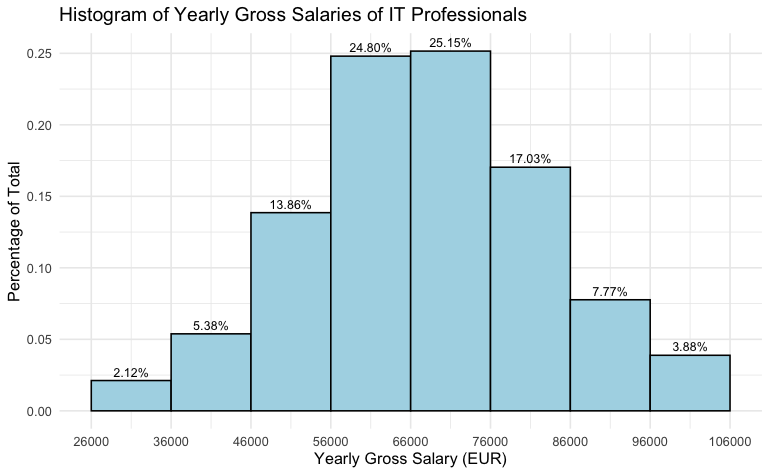

```r
breaks <- seq(26000, 110000, by = 10000)

ggplot(clean_combined_employee, aes(x = `Yearly Brutto Salary (EUR)`)) +
  geom_histogram(aes(y = ..count../sum(..count..)), breaks = breaks, fill = "lightblue", color = "black", na.rm = TRUE) +
  geom_text(aes(y = ..count../sum(..count..), label = sprintf("%.2f%%", ..count../sum(..count..) * 100)),
            stat = "bin", vjust = -0.5, color = "black", size = 3, breaks = breaks) +
  scale_x_continuous(breaks = breaks) +
  labs(title = "Histogram of Yearly Gross Salaries of IT Professionals",
       x = "Yearly Gross Salary (EUR)",
       y = "Percentage of Total") +
  theme_minimal()
```

+) Box plot:

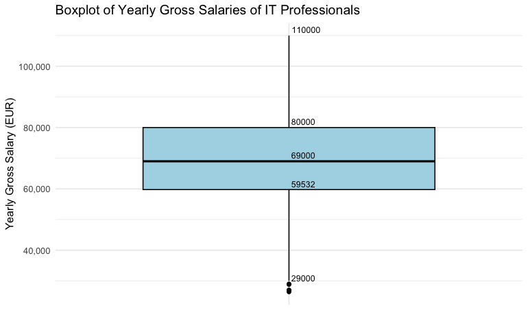

```r
#Calculating statistics
stats <- boxplot.stats(clean_combined_employee$`Yearly Brutto Salary (EUR)`)$stats
stats_df <- data.frame(
  Value = stats)

#Plotting
ggplot(data = clean_combined_employee, aes(x = factor(1), y = `Yearly Brutto Salary (EUR)`)) +
  geom_boxplot(fill = "lightblue", color = "black") +
  geom_text(data = stats_df, aes(x = 1, y = Value, label = stats), size = 3, vjust = -0.5, hjust = -0.1) +
  labs(title = "Boxplot of Yearly Gross Salaries of IT Professionals",
       x = "",
       y = "Yearly Gross Salary (EUR)") +
  scale_x_discrete(labels = NULL) +
  theme_minimal() +
  scale_y_continuous(labels = scales::comma)
```

TASK 4:

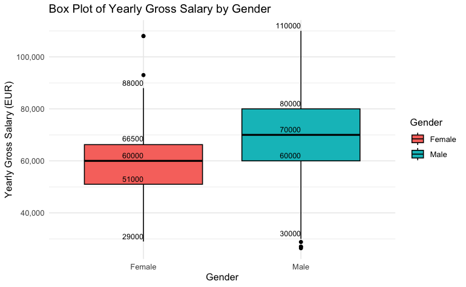

```r
#Creating a new dataframe to prepare data for plotting
task_4_data <- clean_combined_employee %>%
  filter(!is.na(Gender), Gender != "Diverse") %>%  #Removing NAs and Diverse as Diverse has limited records
  group_by(Gender) %>%
  summarise(Stats = list(boxplot.stats(`Yearly Brutto Salary (EUR)`)$stats)) %>%
  unnest_wider(Stats, names_sep = "_") %>%
  pivot_longer(cols = starts_with("Stats_"), names_to = "Statistic", values_to = "Value", names_prefix = "Stats_") %>%
  mutate(Statistic = factor(Statistic, levels = c("min", "q1", "median", "q3", "max")))

# Plotting
ggplot(clean_combined_employee, aes(x = Gender, y = `Yearly Brutto Salary (EUR)`)) +
  geom_boxplot(aes(fill = Gender), color = "black") +
  geom_text(data = task_4_data, aes(x = Gender, y = Value, label = round(Value, 2)),
            position = position_dodge(width = 0.75), vjust = -0.5, hjust = 1, size = 3, color = "black") +
  labs(title = "Box Plot of Yearly Gross Salary by Gender",
       x = "Gender",
       y = "Yearly Gross Salary (EUR)") +
  scale_x_discrete(limits = unique(task_4_data$Gender)) +
  theme_minimal() +
  scale_y_continuous(labels = scales::comma)
```

TASK 5: 1.Relationship between salary and total years of experience

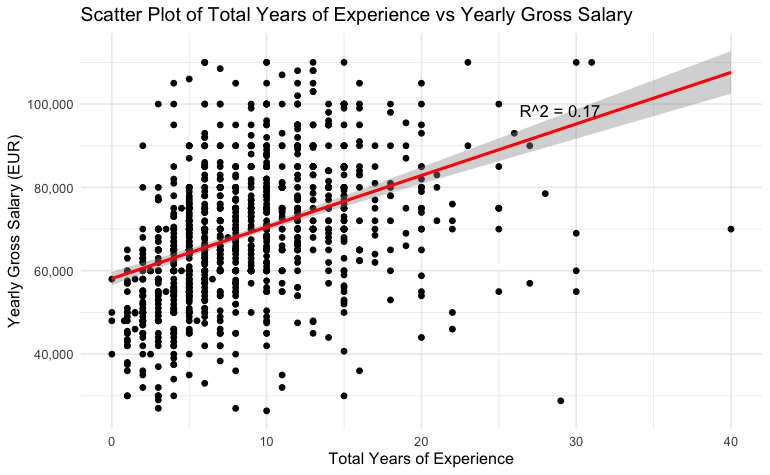

```r
#Preparing data to plot the scatter plot:
task5_data_exp_year <- clean_combined_employee %>%
  filter(!is.na(`Total Years of Experience`), !is.na(`Yearly Brutto Salary (EUR)`))

#Building a linear model for the scatter plot:
model <- lm(`Yearly Brutto Salary (EUR)` ~ `Total Years of Experience`, data = task5_data_exp_year)

#Getting r square
model_summary <- broom::glance(model)
r_squared <- model_summary$r.squared

#Plotting
ggplot(task5_data_exp_year, aes(x = `Total Years of Experience`, y = `Yearly Brutto Salary (EUR)`)) +
  geom_point() +
  geom_smooth(method = "lm", color = "red") +
  annotate("text", x = Inf, y = Inf, label = sprintf("R^2 = %.2f", r_squared), hjust = 3, vjust = 7, color = "black", size = 4) +
  labs(title = "Scatter Plot of Total Years of Experience vs Yearly Gross Salary",
       x = "Total Years of Experience",
       y = "Yearly Gross Salary (EUR)") +
  theme_minimal() +
  scale_y_continuous(labels = scales::comma)
```

2. Relationship between salary and employment status

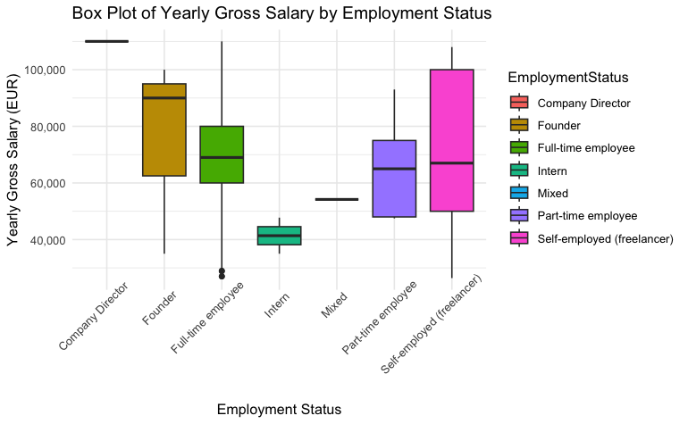

```r
#Preparing data to plot
task5_data_emp_status <- clean_combined_employee %>%
  filter(!is.na(EmploymentStatus), !is.na(`Yearly Brutto Salary (EUR)`))

#Plotting:
ggplot(task5_data_emp_status, aes(x = EmploymentStatus, y = `Yearly Brutto Salary (EUR)`, fill = EmploymentStatus)) +
  geom_boxplot() +
  labs(title = "Box Plot of Yearly Gross Salary by Employment Status",
       x = "Employment Status",
       y = "Yearly Gross Salary (EUR)") +
  theme_minimal() +
  theme(axis.text.x = element_text(angle = 45, hjust = 0.75)) +
  scale_y_continuous(labels = scales::comma)
```

3. Relationship between salary and company size

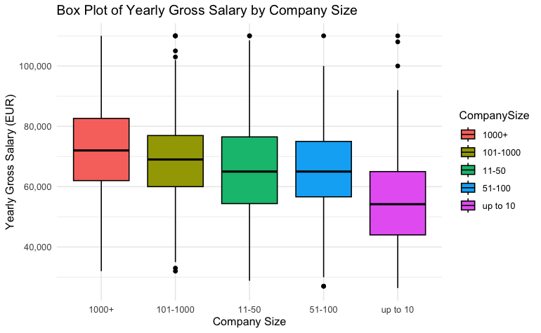

```r
task5_data_comp_size <- clean_combined_employee %>%
  filter(!is.na(CompanySize))

ggplot(task5_data_comp_size, aes(x = CompanySize, y = `Yearly Brutto Salary (EUR)`)) +
  geom_boxplot(aes(fill = CompanySize), color = "black", na.rm = TRUE) +
  labs(title = "Box Plot of Yearly Gross Salary by Company Size",
       x = "Company Size",
       y = "Yearly Gross Salary (EUR)") +
  theme_minimal() +
  scale_y_continuous(labels = scales::comma)
```

4. Relationship between salary and position

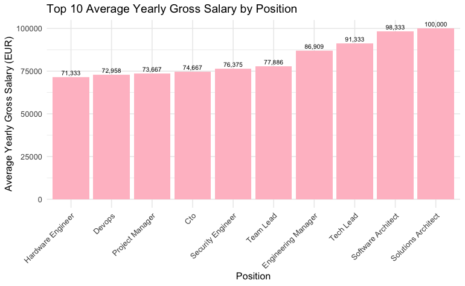

```r
salary_by_position <- clean_combined_employee %>%
  group_by(Position) %>%
  filter(!is.na(Position), !is.na(`Yearly Brutto Salary (EUR)`)) %>%
  summarise(Count = n(), AverageSalary = round(mean(`Yearly Brutto Salary (EUR)`, na.rm = TRUE))) %>%
  arrange(desc(AverageSalary)) %>%
  filter(Count > 2) %>% #removing the variables have less than 2 counts to remove noise in analysis, as they have too limited records for effective analysis
  slice_head(n = 10)

# Create a bar chart
ggplot(salary_by_position, aes(x = reorder(Position, AverageSalary), y = AverageSalary)) +
  geom_bar(stat = "identity", fill = "pink") +
  labs(title = "Top 10 Average Yearly Gross Salary by Position",
       x = "Position",
       y = "Average Yearly Gross Salary (EUR)") +
  theme_minimal() +
  geom_text(aes(label = scales::comma(AverageSalary)), vjust = -0.5, color = "black", size = 2.5) +
  theme(axis.text.x = element_text(angle = 45, hjust = 1))
```

5. Relationship between salary and seniority level:

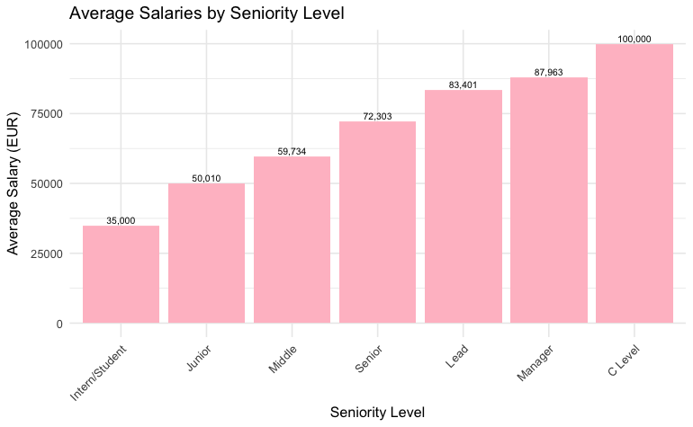

```r
salary_by_seniority <- clean_combined_employee %>%
  group_by(SeniorityLevel) %>%
  filter(!is.na(SeniorityLevel), !is.na(`Yearly Brutto Salary (EUR)`)) %>%
  dplyr::summarize(AverageSalary = mean(`Yearly Brutto Salary (EUR)`, na.rm = TRUE)) %>%
  arrange(desc(AverageSalary))

#Plotting:
ggplot(salary_by_seniority, aes(x = reorder(SeniorityLevel, AverageSalary), y = AverageSalary)) +
  geom_bar(stat = "identity", fill = "pink") +
  labs(title = "Average Salaries by Seniority Level",
       x = "Seniority Level",
       y = "Average Salary (EUR)") +
  theme_minimal() +
  geom_text(aes(label = scales::comma(AverageSalary)), vjust = -0.3, color = "black", size = 2.5) +
  theme(axis.text.x = element_text(angle = 45, hjust = 1))
```